# HOMEWORK 3

ilaydacelenk

16/11/2020

```r
#importing the libraries
library(MLmetrics)
library(tidyr)
library(dplyr)
library(reshape2)
library(ggplot2)
library(tidyverse)
library(glmnet)
library(CVXR)
library(lubridate)
```

### Introduction:

This assignment will focus on regression approaches to forecast the next day’s hourly electricity consumption. The approaches will be compared according to mean absolute percentage error(MAPE) values. We will learn the model using the train data and compare the model results using test data.

### Data Collection:

Let’s read the data from the repository and rename the columns. Then we can manipulate the data structures. For example `Consumption` values include both “,” and “.” separators, therefore it is wise to use . only. Also, for simplicity, `Hour` values are be mapped into 0, 1, .., 23.

```r
raw <-  read.csv("https://raw.githubusercontent.com/BU-IE-582/fall20-ilaydacelenk/master/files/hw3_data.csv")

set.seed(150)

data <- rename(raw,
    Date = Date,
    Hour = Hour,
    Consumption = Consumption..MWh.) %>% mutate(Consumption = as.numeric(sub(",", "", Consumption, fixed = TRUE))) %>% mutate(Hour = as.character(as.numeric(factor(Hour))-1))

data %>% glimpse()
```

```
FALSE Rows: 43,104
FALSE Columns: 3
FALSE $ Date        <chr> "01.01.2016", "01.01.2016", "01.01.2016", "01.01.2016", "…
FALSE $ Hour        <chr> "0", "1", "2", "3", "4", "5", "6", "7", "8", "9", "10", "…
FALSE $ Consumption <dbl> 26277.24, 24991.82, 23532.61, 22464.78, 22002.91, 21957.0…
```

### Tasks:

#### Naive Approaches

We also observe that for 27.03.2016 we have 2 rows of hour 4 and there is no row for hour 3. We will remove this entire date as discussed in class. After creating the table with lag values, we will need to remove the dates 27.03.2016, 29.03.2016 and 03.04.2016. The last 2 dates will also be removed since they would need to use 2 and 7 days lag values from 27.03.2016.

```r
data <- data %>% mutate(lag_48 = lag(Consumption, 48, na.pad = TRUE), lag_168 = lag(Consumption, 168, na.pad = TRUE))

test <- data %>% tail(30*24)
train <- data %>% head(-30*24)

#manipulating noisy data
train48 <- train %>% drop_na(lag_48) %>% filter(!(Date %in% c("27.03.2016", "29.03.2016", "03.04.2016")))
train168 <- train %>% drop_na(lag_168) %>% filter(!(Date %in% c("27.03.2016", "29.03.2016", "03.04.2016")))

lag48_error <- MAPE(test$lag_48, test$Consumption)
lag168_error <- MAPE(test$lag_168, test$Consumption)
```

Using the lag consumption values as our forecast, the mean absolute percentage errors(MAPE) are computed as 7.79% and 3.45% for the lag 48 and lag 168 values respectively.

#### Multiple Linear Regression with Lags as Features

Now, we treat lag consumption values as features to build a regression model. Here we teach the model using the train data removing NA rows.

```r
linear_model <- lm(Consumption ~ lag_48 + lag_168, train168)
summary(linear_model)
```

```
FALSE
FALSE Call:
FALSE lm(formula = Consumption ~ lag_48 + lag_168, data = train168)
FALSE
FALSE Residuals:
FALSE      Min       1Q   Median       3Q      Max
FALSE -17125.7   -984.3     -1.2   1015.7  16097.4
FALSE
FALSE Coefficients:
FALSE              Estimate Std. Error t value Pr(>|t|)
FALSE (Intercept) 1.570e+03  8.351e+01   18.80   <2e-16 ***
FALSE lag_48      3.091e-01  3.096e-03   99.82   <2e-16 ***
FALSE lag_168     6.430e-01  3.094e-03  207.83   <2e-16 ***
FALSE ---
FALSE Signif. codes:  0 '***' 0.001 '**' 0.01 '*' 0.05 '.' 0.1 ' ' 1
FALSE
FALSE Residual standard error: 2388 on 42141 degrees of freedom
FALSE Multiple R-squared:  0.7757,  Adjusted R-squared:  0.7757
FALSE F-statistic: 7.288e+04 on 2 and 42141 DF,  p-value: < 2.2e-16
```

```r
linear_error <- MAPE(predict(linear_model, newdata = test), test$Consumption)
```

Then we make the prediction on the test data and calculated MAPE value is 4.12%, which is not better than the naive method with lag 168 values.

#### Seasonality

Energy consumption may be affected by hourly seasonality. Therefore, in order to account for it better than the previous part, we can model each hour separately and train the models for each hour. Since there are 24 hours, there will be 24 models. Again we will use the train data for lag_168 due to the same reason as above. We filter the train data according to each `Hour` value, then create a model. Afterwards, we predict values using test data and create a column named `pred` which is consisted of the predicted values. After doing this for all of the hours, we combine rows in order to get the overall test and prediction values on one table.

```r
#do not forget to put train168 instead of train
seasonality <- function(train_data, test_data, hour){
  train_hourly <- train_data %>% filter(Hour==hour)
  model <- lm(Consumption ~ lag_48 + lag_168, train_hourly)
  test_hourly <- test_data %>% filter(Hour==hour) %>% mutate(pred=predict(model, newdata = .))
  return(test_hourly)
}

sum <- 0
seasonal_pred <- seasonality(train168, test, 0)
sum <- MAPE(seasonal_pred$pred, seasonal_pred$Consumption)
for(i in 1:23)
{
  seasonal_pred <- rbind(seasonal_pred, seasonality(train168, test, i))
  sum <- sum + MAPE(seasonal_pred$pred, seasonal_pred$Consumption)
}

avg_mape <- sum/24

seasonal_error <- MAPE(seasonal_pred$pred, seasonal_pred$Consumption)
```

The average MAPE value is 3.92%. And, after binding all the predictions we calculate the MAPE value, which is found as 4.25%. Again, there is no improvement.

#### Hourly Consumption of Last Week’s Same Day with Lasso Regression

Again, we remove the rows with NA values at the beginning. For the train data we will use lag 48 and lag 168 values and it will have 1756 rows and test data will have 30 rows. Each row will represent a date and it will consist the consumption values of same day’s 24 hours and 24 hours from 7 days ago and also 24 hours from 2 days ago. So we will try to use the 48 hours from 2 and 7 days in order to predict each 24 hours belonging to the current date. This means 24 models each using 48 features. I choose lambda.min value to use in predictions.

```r
test_wide <- test %>% rename (Lag_day7=lag_168, Lag_day2=lag_48) %>% pivot_wider(names_from=Hour, values_from=c(Lag_day7,Lag_day2, Consumption), names_prefix=c("hour_", "hour_")) %>% unnest()

train_wide <- train168 %>% rename (Lag_day7=lag_168, Lag_day2=lag_48) %>% pivot_wider(names_from=Hour, values_from=c(Lag_day7,Lag_day2, Consumption), names_prefix=c("hour_", "hour_")) %>% unnest()
```

We have transformed the data into the wide format from the long format. We see that the features have strong autocorrelation, therefore we will use a penalized regression approach for modeling as suggested.

Here we can see the summary of the model for the 23rd hour as an example.

```r
#I will be removing Date column, so just in case store them in vectors
train_date <- as.Date(train_wide$Date,format="%d.%m.%y")
test_date <- as.Date(test_wide$Date,format="%d.%m.%y")

#Since cv.glmnet takes matrices, we convert the dataset
#each row is an observation row so I removed Date column since it's not a feature
train_matrix_features <- train_wide[, 2:49] %>% data.matrix()
test_matrix_features <- test_wide[, 2:49] %>% data.matrix()

#predicting consumption hour 0, using Lag_day7_hour_0 to 23 and Lag_day2_hour_0 to 23, i.e 48 features
#to predict hour 0, we'll use 50th column of train_wide and test_wide
#to predict hour 23, we'll use 73rd column of train_wide and test_wide

#alpha=1 for lasso, nfolds=10 is asked

#print(model)
#plot(model)
#coef(model,s="lambda.min")

model0 <- cv.glmnet(x=train_matrix_features, y=train_wide$Consumption_hour_0, family="gaussian", nfolds = 10, alpha=1)
model1 <- cv.glmnet(x=train_matrix_features, y=train_wide$Consumption_hour_1, family="gaussian", nfolds = 10, alpha=1)
model2 <- cv.glmnet(x=train_matrix_features, y=train_wide$Consumption_hour_2, family="gaussian", nfolds = 10, alpha=1)
model3 <- cv.glmnet(x=train_matrix_features, y=train_wide$Consumption_hour_3, family="gaussian", nfolds = 10, alpha=1)
model4 <- cv.glmnet(x=train_matrix_features, y=train_wide$Consumption_hour_4, family="gaussian", nfolds = 10, alpha=1)
model5 <- cv.glmnet(x=train_matrix_features, y=train_wide$Consumption_hour_5, family="gaussian", nfolds = 10, alpha=1)
model6 <- cv.glmnet(x=train_matrix_features, y=train_wide$Consumption_hour_6, family="gaussian", nfolds = 10, alpha=1)
model7 <- cv.glmnet(x=train_matrix_features, y=train_wide$Consumption_hour_7, family="gaussian", nfolds = 10, alpha=1)
model8 <- cv.glmnet(x=train_matrix_features, y=train_wide$Consumption_hour_8, family="gaussian", nfolds = 10, alpha=1)
model9 <- cv.glmnet(x=train_matrix_features, y=train_wide$Consumption_hour_9, family="gaussian", nfolds = 10, alpha=1)
model10 <- cv.glmnet(x=train_matrix_features, y=train_wide$Consumption_hour_10, family="gaussian", nfolds = 10, alpha=1)
model11 <- cv.glmnet(x=train_matrix_features, y=train_wide$Consumption_hour_11, family="gaussian", nfolds = 10, alpha=1)
model12 <- cv.glmnet(x=train_matrix_features, y=train_wide$Consumption_hour_12, family="gaussian", nfolds = 10, alpha=1)
model13 <- cv.glmnet(x=train_matrix_features, y=train_wide$Consumption_hour_13, family="gaussian", nfolds = 10, alpha=1)
model14 <- cv.glmnet(x=train_matrix_features, y=train_wide$Consumption_hour_14, family="gaussian", nfolds = 10, alpha=1)
model15 <- cv.glmnet(x=train_matrix_features, y=train_wide$Consumption_hour_15, family="gaussian", nfolds = 10, alpha=1)
model16 <- cv.glmnet(x=train_matrix_features, y=train_wide$Consumption_hour_16, family="gaussian", nfolds = 10, alpha=1)
model17 <- cv.glmnet(x=train_matrix_features, y=train_wide$Consumption_hour_17, family="gaussian", nfolds = 10, alpha=1)
model18 <- cv.glmnet(x=train_matrix_features, y=train_wide$Consumption_hour_18, family="gaussian", nfolds = 10, alpha=1)
model19 <- cv.glmnet(x=train_matrix_features, y=train_wide$Consumption_hour_19, family="gaussian", nfolds = 10, alpha=1)
model20 <- cv.glmnet(x=train_matrix_features, y=train_wide$Consumption_hour_20, family="gaussian", nfolds = 10, alpha=1)
model21 <- cv.glmnet(x=train_matrix_features, y=train_wide$Consumption_hour_21, family="gaussian", nfolds = 10, alpha=1)
model22 <- cv.glmnet(x=train_matrix_features, y=train_wide$Consumption_hour_22, family="gaussian", nfolds = 10, alpha=1)
model23 <- cv.glmnet(x=train_matrix_features, y=train_wide$Consumption_hour_23, family="gaussian", nfolds = 10, alpha=1)

pred_hour <- test %>% select(-lag_168, -lag_48)
pred_hour0 <- pred_hour %>% filter(Hour==0) %>% mutate(pred=predict(model0, newx=test_matrix_features ,s=c("lambda.min")))
pred_hour1 <- pred_hour %>% filter(Hour==1) %>% mutate(pred=predict(model1, newx=test_matrix_features ,s=c("lambda.min")))
pred_hour2 <- pred_hour %>% filter(Hour==2) %>% mutate(pred=predict(model2, newx=test_matrix_features ,s=c("lambda.min")))
pred_hour3 <- pred_hour %>% filter(Hour==3) %>% mutate(pred=predict(model3, newx=test_matrix_features ,s=c("lambda.min")))
pred_hour4 <- pred_hour %>% filter(Hour==4) %>% mutate(pred=predict(model4, newx=test_matrix_features ,s=c("lambda.min")))
pred_hour5 <- pred_hour %>% filter(Hour==5) %>% mutate(pred=predict(model5, newx=test_matrix_features ,s=c("lambda.min")))
pred_hour6 <- pred_hour %>% filter(Hour==6) %>% mutate(pred=predict(model6, newx=test_matrix_features ,s=c("lambda.min")))
pred_hour7 <- pred_hour %>% filter(Hour==7) %>% mutate(pred=predict(model7, newx=test_matrix_features ,s=c("lambda.min")))
pred_hour8 <- pred_hour %>% filter(Hour==8) %>% mutate(pred=predict(model8, newx=test_matrix_features ,s=c("lambda.min")))
pred_hour9 <- pred_hour %>% filter(Hour==9) %>% mutate(pred=predict(model9, newx=test_matrix_features ,s=c("lambda.min")))
pred_hour10 <- pred_hour %>% filter(Hour==10) %>% mutate(pred=predict(model10, newx=test_matrix_features ,s=c("lambda.min")))
pred_hour11 <- pred_hour %>% filter(Hour==11) %>% mutate(pred=predict(model11, newx=test_matrix_features ,s=c("lambda.min")))
pred_hour12 <- pred_hour %>% filter(Hour==12) %>% mutate(pred=predict(model12, newx=test_matrix_features ,s=c("lambda.min")))
pred_hour13 <- pred_hour %>% filter(Hour==13) %>% mutate(pred=predict(model13, newx=test_matrix_features ,s=c("lambda.min")))
pred_hour14 <- pred_hour %>% filter(Hour==14) %>% mutate(pred=predict(model14, newx=test_matrix_features ,s=c("lambda.min")))
pred_hour15 <- pred_hour %>% filter(Hour==15) %>% mutate(pred=predict(model15, newx=test_matrix_features ,s=c("lambda.min")))
pred_hour16 <- pred_hour %>% filter(Hour==16) %>% mutate(pred=predict(model16, newx=test_matrix_features ,s=c("lambda.min")))
pred_hour17 <- pred_hour %>% filter(Hour==17) %>% mutate(pred=predict(model17, newx=test_matrix_features ,s=c("lambda.min")))
pred_hour18 <- pred_hour %>% filter(Hour==18) %>% mutate(pred=predict(model18, newx=test_matrix_features ,s=c("lambda.min")))
pred_hour19 <- pred_hour %>% filter(Hour==19) %>% mutate(pred=predict(model19, newx=test_matrix_features ,s=c("lambda.min")))
pred_hour20 <- pred_hour %>% filter(Hour==20) %>% mutate(pred=predict(model20, newx=test_matrix_features ,s=c("lambda.min")))
pred_hour21 <- pred_hour %>% filter(Hour==21) %>% mutate(pred=predict(model21, newx=test_matrix_features ,s=c("lambda.min")))
pred_hour22 <- pred_hour %>% filter(Hour==22) %>% mutate(pred=predict(model22, newx=test_matrix_features ,s=c("lambda.min")))
pred_hour23 <- pred_hour %>% filter(Hour==23) %>% mutate(pred=predict(model23, newx=test_matrix_features ,s=c("lambda.min")))


lasso_pred <- rbind(pred_hour0, pred_hour1, pred_hour2, pred_hour3, pred_hour4, pred_hour5, pred_hour6, pred_hour7, pred_hour8, pred_hour9, pred_hour10, pred_hour11, pred_hour12, pred_hour13, pred_hour14, pred_hour15, pred_hour16, pred_hour17, pred_hour18, pred_hour19, pred_hour20, pred_hour21, pred_hour22, pred_hour23)

lasso_error <- MAPE(lasso_pred$pred, lasso_pred$Consumption)

summary(model23)
```

```
FALSE            Length Class  Mode
FALSE lambda     100    -none- numeric
FALSE cvm        100    -none- numeric
FALSE cvsd       100    -none- numeric
FALSE cvup       100    -none- numeric
FALSE cvlo       100    -none- numeric
FALSE nzero      100    -none- numeric
FALSE call         6    -none- call
FALSE name         1    -none- character
FALSE glmnet.fit  12    elnet  list
FALSE lambda.min   1    -none- numeric
FALSE lambda.1se   1    -none- numeric
```

Using penalized lasso approach, we got 2.43% as the MAPE value and this is the best so far.

```r
y <- train_wide$Consumption_hour_0
X <- cbind(1,train_matrix_features)
```

#### Comparing the Results

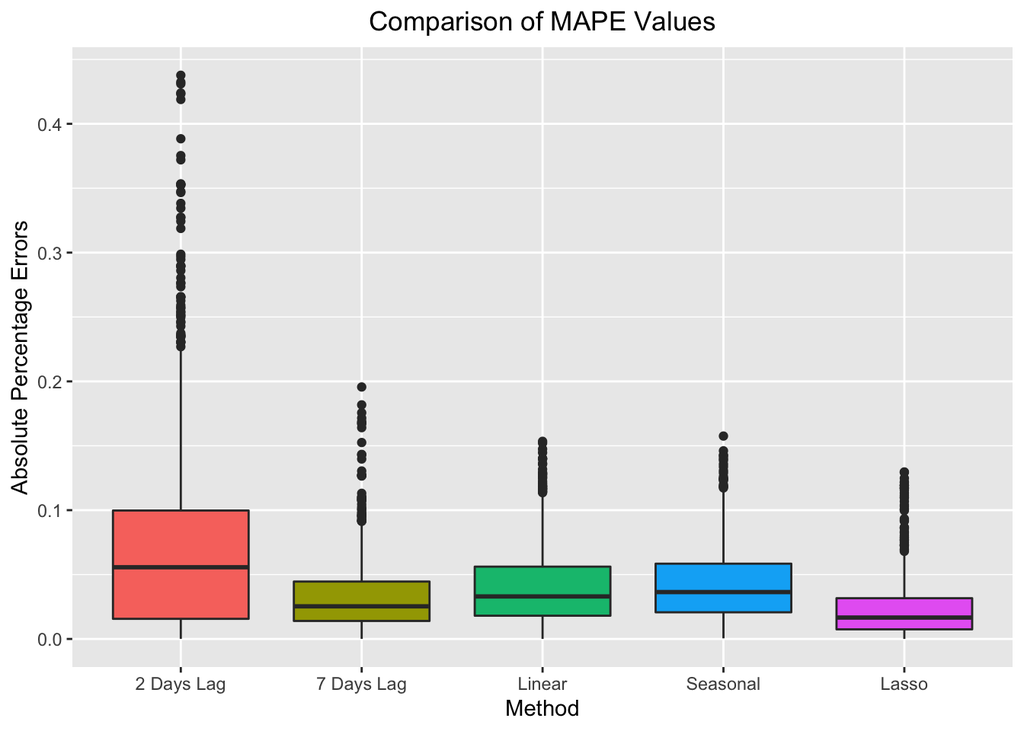

```r
#ape=absolute percentage error without taking the mean
all_pred <- lasso_pred %>% rename(lasso_pred=pred) %>% full_join(.,test,by=c("Date", "Hour", "Consumption")) %>% mutate(linear_pred=predict(linear_model, newdata = .)) %>% full_join(.,seasonal_pred,by=c("Date", "Hour", "Consumption", "lag_48", "lag_168")) %>% rename(seasonal_pred=pred) %>% mutate(ape_lasso = (abs(Consumption-lasso_pred)/Consumption), ape_48 = (abs(Consumption-lag_48)/Consumption), ape_168 = (abs(Consumption-lag_168)/Consumption), ape_linear = (abs(Consumption-linear_pred)/Consumption), ape_seasonal = (abs(Consumption-seasonal_pred)/Consumption))

long <- all_pred %>% select(Date, Hour, Consumption, ape_48, ape_168, ape_linear, ape_seasonal, ape_lasso) %>% melt(id.vars = c("Date", "Hour", "Consumption")) %>% mutate(Absolute_perc_error=value, Model=variable)

ggplot(long) + geom_boxplot(aes(y=Absolute_perc_error, x=Model, fill=Model)) + xlab("Method") + ylab("Absolute Percentage Errors") + theme(plot.title=element_text(hjust = 0.5)) + ggtitle("Comparison of MAPE Values") + scale_x_discrete(labels=c("2 Days Lag","7 Days Lag","Linear", "Seasonal", "Lasso")) + theme(legend.position = "none")
```

```r
print(long %>% group_by(Model) %>% summarise(MAPE=mean(Absolute_perc_error), max=max(Absolute_perc_error)))
```

```
FALSE # A tibble: 5 x 3
FALSE   Model          MAPE   max
FALSE   <fct>         <dbl> <dbl>
FALSE 1 ape_48       0.0779 0.438
FALSE 2 ape_168      0.0345 0.196
FALSE 3 ape_linear   0.0412 0.153
FALSE 4 ape_seasonal 0.0425 0.158
FALSE 5 ape_lasso    0.0243 0.130
```

### Reference

[1] Dataset: Electricity Consumption data from 1st of January, 2016 till the 1st of December, 2020 from [Energy Exchange Istanbul(EXIST) Webpage](https://seffaflik.epias.com.tr/transparency/tuketim/gerceklesen-tuketim/gercek-zamanli-tuketim.xhtml).